# Progetto di fondamenti di scienza dei dati e laboratorio

Filippo Marcolini 167926

è possibile far passare le scommesse calcistiche da “gioco d’azzardo” ad una forma di investimento sicura?

# L'ARBITRAGGIO

Che cos'è l'arbitraggio?

Scommettere su tutti i possibili esiti di un evento sfruttando le diverse quote offerte da diversi bookmakers

[figure not shown]

# IL DATASET

Ho utilizzato i dataset offerti da questo sito: https://www.football-data.co.uk/data.php

Cosa contengono?

- Un totale di 11583 partite tra le stagioni 2022/2023 e 2023/2024 di campionati di 11 nazioni
- Il risultato e diverse statistiche per ogni partita
- Diversi tipi di quote offerte da diversi bookmakers per ogni partita

## Quali sono i limiti dei dati che avevo a disposizione?

- Non sono presenti alcune quote per partite di divisioni minori
- Le quote presenti nel dataset sono di un numero limitato di bookmakers
- Le quote presenti nel dataset sono registrate al fischio d'inizio

# Che domande mi sono posto?

- Qual è il tipo di quota più soggetto all'arbitraggio?
- Quali sono i campionati dove conviene cercare?
- A che ritorno sull'investimento si può ambire?

## Qual è il tipo di quota più soggetto all'arbitraggio?

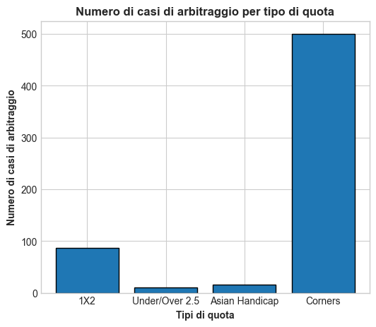

## Quali sono i campionati dove conviene cercare?

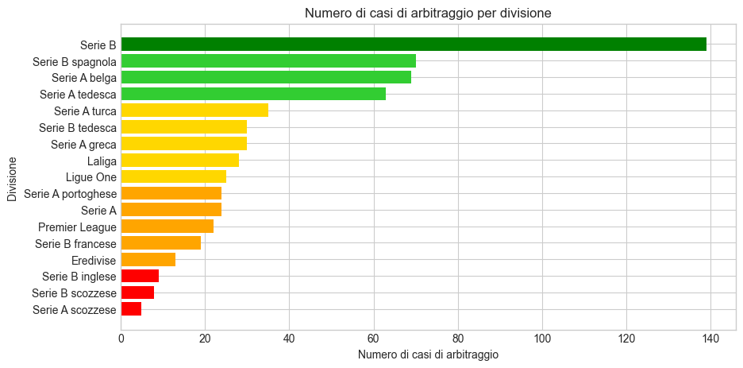

coefficiente di correlazione di Pearson: 0.273

## Distribuzione dei casi di arbitraggio

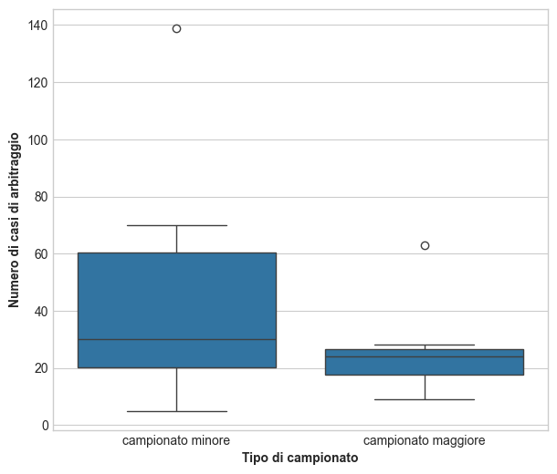

## A che ritorno sull'investimento si può ambire?

ROI medio:

```
1.64%
```

ROI massimo:

```
12.64%
```

## Ritorno sull'investimento medio per tipo di quota

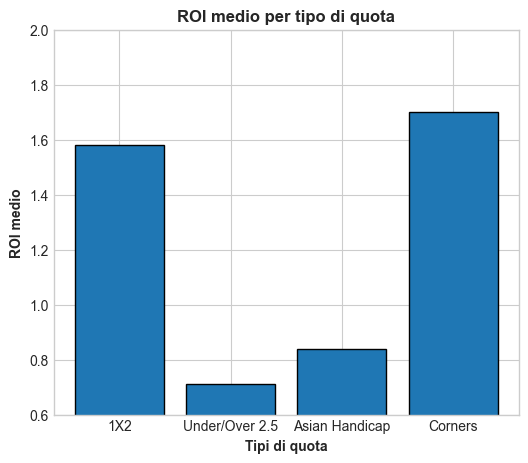

# Conclusioni:

- La quota più conveniente in generale per cercare casi di arbitraggio sono i calci d'angolo
- Generalmente, conviene cercare casi di arbitraggio in campionati minori